# Linh Le - Time Series for Anomaly Detection on Netflix Stock Data

```python
!pip install plotly
```

```python
from prophet import Prophet
import pandas as pd
import matplotlib.pyplot as plt
import numpy as np
np.float_ = np.float64
import matplotlib.ticker as mticker
from prophet import Prophet
```

```python
df = pd.read_csv('/Users/linhle/Downloads/Netflix Stock Data (20215-2025).csv')
df['Date'] = pd.to_datetime(df['Date'], format="%m/%d/%y")
df = df.sort_values('Date')
df = df.rename(columns={'Close/Last': 'y'})
df['y'] = df['y'].replace(r'[\$,]', '', regex=True).astype(float)
```

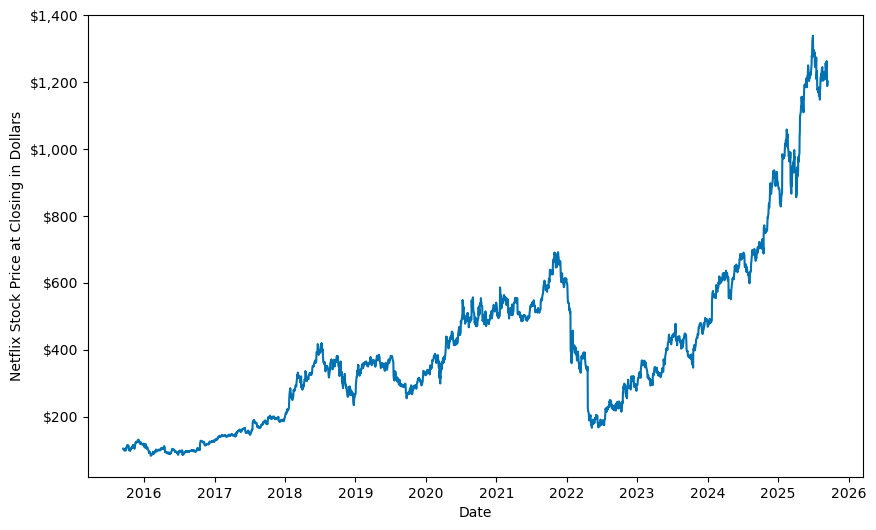

```python
import matplotlib.ticker as mticker
plt.figure(figsize=(10, 6))
plt.plot(df['Date'], df['y'], color='#0072B2')

plt.xlabel("Date")
plt.ylabel("Netflix Stock Price at Closing in Dollars")

plt.gca().yaxis.set_major_formatter(mticker.StrMethodFormatter('${x:,.0f}'))

plt.show()
```

# **Simple Moving Average**

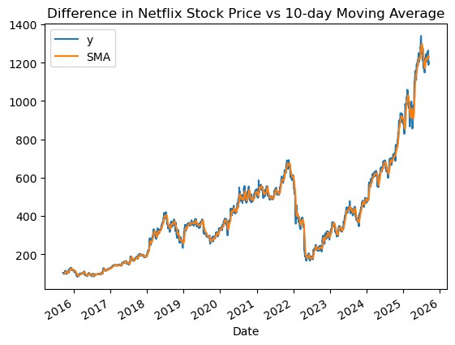

```python
df['SMA'] = df.loc[:,['y']].rolling(window=10).mean()
df['diff'] = df['y'] - df['SMA']
df = df.set_index('Date')
df[['y','SMA']].plot(title='Difference in Netflix Stock Price vs 10-day Moving Average')
```

By looking at the histograms distribution of raw Netflix stock price with a 10 day MA, we can identify the times when the stockprice is further from the clusters. Future analysis should include a longer window to identify structural anamolies.

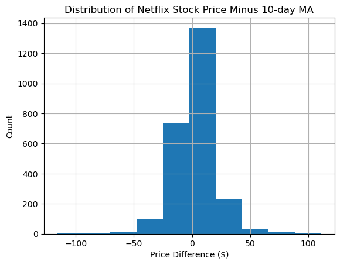

```python
hist_plot = df['diff'].hist()
plt.title('Distribution of Netflix Stock Price Minus 10-day MA')
plt.xlabel('Price Difference ($)')
plt.ylabel('Count')
```

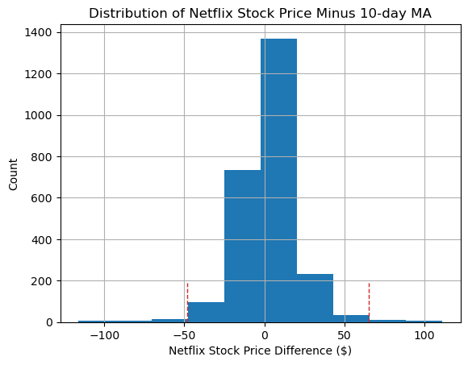

```python
hist_plot = df['diff'].hist()
plt.title('Distribution of Netflix Stock Price Minus 10-day MA')
plt.xlabel('Netflix Stock Price Difference ($)')
plt.ylabel('Count')
hist_plot.vlines(x=[-48,65], ymin=0, ymax=190, colors=['tab:red', 'tab:red'], ls='--', lw=1)
```

# **Exponential Moving Average**

```python
!pip install statsmodels
```

[output not shown]

```python
print(df.columns)
```

[output not shown]

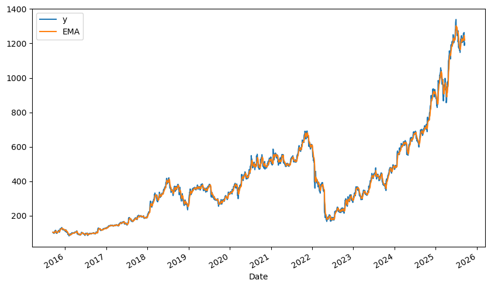

```python
from statsmodels.tsa.api import SimpleExpSmoothing

EMAfit = SimpleExpSmoothing(df['y']).fit(smoothing_level=0.3,optimized=False)
EMA = EMAfit.forecast(3).rename(r'$\alpha=0.3$')
df['EMA'] = EMAfit.predict(start = 0)
df['diff'] = df['y'] - df['EMA']
df[['y','EMA']].plot(figsize=(10,6))
```

**Trying different smoothing level since Netflix stock price is quite volatile and add anamolies**

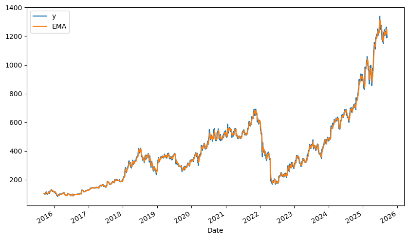

```python
from statsmodels.tsa.api import SimpleExpSmoothing

EMAfit = SimpleExpSmoothing(df['y']).fit(smoothing_level=0.4,optimized=False)
EMA = EMAfit.forecast(3).rename(r'$\alpha=0.4$')
df['EMA'] = EMAfit.predict(start = 0)
df['diff'] = df['y'] - df['EMA']
df[['y','EMA']].plot(figsize=(10,6))
```

```python
def plot_it():
    plt.plot(df['y'] ,'go',markersize=0.4,label='Actual')
    plt.fill_between(
       df.index, df['lower'], df['upper'], alpha=1, color="r")
    plt.xlabel("Date")
    plt.ylabel("Values and Outlier Thresholds")
    plt.show()
```

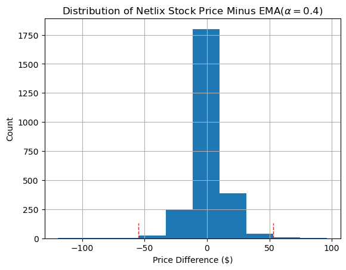

```python
hist_plot = df['diff'].hist()
plt.title('Distribution of Netlix Stock Price Minus EMA('+ r'$\alpha=0.4$)')
plt.xlabel('Price Difference ($)')
plt.ylabel('Count')
upper_threshold = 53
lower_threshold = -55
hist_plot.vlines(x=[lower_threshold, upper_threshold], ymin=0, ymax=130, colors=['tab:red', 'tab:red'], ls='--', lw=1)
```

**Using dynamic thresholds for better response to volatility**

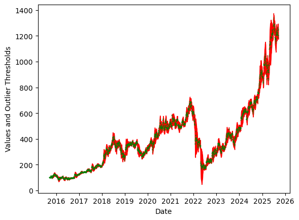

```python
from statsmodels.tsa.api import SimpleExpSmoothing
EMAfit = SimpleExpSmoothing(df['y']).fit(smoothing_level=0.4, optimized=False)
df['EMA'] = EMAfit.fittedvalues
rolling_std = df['y'].rolling(window=30).std()
df['upper'] = df['EMA'] + 1.5*rolling_std
df['lower'] = df['EMA'] - 1.5*rolling_std
plot_it()
```

```python
anomalies = df[(df['y'] > df['upper']) | (df['y'] < df['lower'])]
print(anomalies)
```

```
                  y       SMA       diff          EMA        upper  \
Date
2016-04-19    94.34   105.707 -14.758338   109.098338   115.650245
2016-07-19    85.84    95.489 -12.131307    97.971307   103.667781
2016-09-21    94.88    97.632  -3.301033    98.181033   100.481736
2016-10-03   102.63    97.186   5.199229    97.430771   100.018613
2016-10-05   106.28    98.735   5.637722   100.642278   104.296737
...             ...       ...        ...          ...          ...
2025-04-22  1040.34   952.580  69.416056   970.923944  1031.419975
2025-04-24  1096.87   985.639  77.819780  1019.050220  1096.832753
2025-07-18  1209.24  1260.485 -54.519693  1263.759693  1317.252223
2025-09-11  1203.50  1234.051 -45.564360  1249.064360  1293.156028
2025-09-12  1188.44  1229.750 -42.398616  1230.838616  1272.811619

                  lower
Date
2016-04-19   102.546432
2016-07-19    92.274834
2016-09-21    95.880331
2016-10-03    94.842929
2016-10-05    96.987819
...                 ...
2025-04-22   910.427914
2025-04-24   941.267687
2025-07-18  1210.267163
2025-09-11  1204.972693
2025-09-12  1188.865613

[129 rows x 6 columns]
```

Anamolies are highlighted after applying alpha of 0.4 and rolling standard.

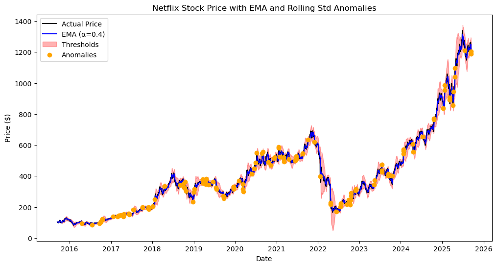

```python
plt.figure(figsize=(12,6))
plt.plot(df.index, df['y'], color='black', label='Actual Price')
plt.plot(df.index, df['EMA'], color='blue', label='EMA (α=0.4)')
plt.fill_between(df.index, df['lower'], df['upper'], color='red', alpha=0.3, label='Thresholds')

plt.scatter(anomalies.index, anomalies['y'], color='orange', label='Anomalies', zorder=5)

plt.title("Netflix Stock Price with EMA and Rolling Std Anomalies")
plt.xlabel("Date")
plt.ylabel("Price ($)")
plt.legend()
plt.show()
```

### **Winsorizing**

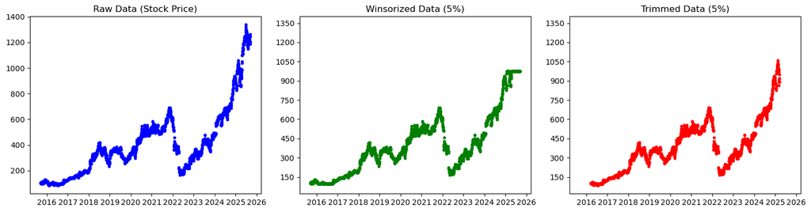

```python
from scipy import stats
from matplotlib.ticker import MaxNLocator


x = df.index
y = df['y'].values

fig = plt.figure(figsize=(15, 4))

ax1 = fig.add_subplot(1, 3, 1)
ax1.plot(x, y, 'b.')
ax1.title.set_text('Raw Data (Stock Price)')

# 2. Winsorized Data (clip extreme 5%)
winsorized_y = stats.mstats.winsorize(y, limits=[0.05, 0.05])
ax2 = fig.add_subplot(1, 3, 2)
ax2.plot(x, winsorized_y, 'g.')
ax2.title.set_text('Winsorized Data (5%)')
ax2.yaxis.set_major_locator(MaxNLocator(integer=True))
ax2.set_xlim(ax1.get_xlim())
ax2.set_ylim(ax1.get_ylim())

# 3. Trimmed Data (remove 5% from both ends)
trim_size = int(0.05 * len(y))
trimmed_x = x[trim_size:-trim_size]
trimmed_y = y[trim_size:-trim_size]
ax3 = fig.add_subplot(1, 3, 3)
ax3.plot(trimmed_x, trimmed_y, 'r.')
ax3.title.set_text('Trimmed Data (5%)')
ax3.yaxis.set_major_locator(MaxNLocator(integer=True))
ax3.set_xlim(ax1.get_xlim())
ax3.set_ylim(ax1.get_ylim())

plt.tight_layout()
plt.show()
```

**Experiment with different percentage level**

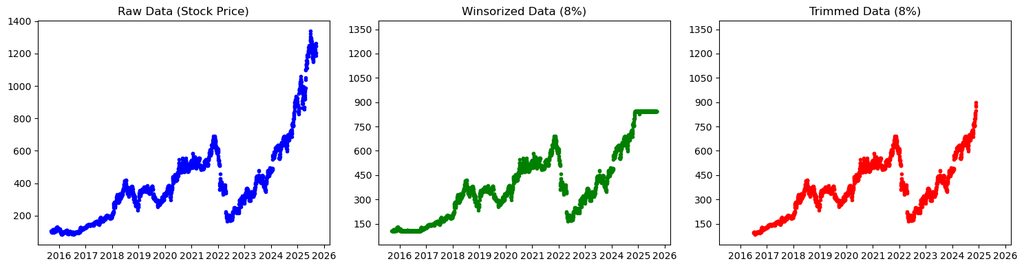

```python
from scipy import stats
from matplotlib.ticker import MaxNLocator


x = df.index
y = df['y'].values

fig = plt.figure(figsize=(15, 4))

ax1 = fig.add_subplot(1, 3, 1)
ax1.plot(x, y, 'b.')
ax1.title.set_text('Raw Data (Stock Price)')

winsorized_y = stats.mstats.winsorize(y, limits=[0.08, 0.08])
ax2 = fig.add_subplot(1, 3, 2)
ax2.plot(x, winsorized_y, 'g.')
ax2.title.set_text('Winsorized Data (8%)')
ax2.yaxis.set_major_locator(MaxNLocator(integer=True))
ax2.set_xlim(ax1.get_xlim())
ax2.set_ylim(ax1.get_ylim())

trim_size = int(0.08 * len(y))
trimmed_x = x[trim_size:-trim_size]
trimmed_y = y[trim_size:-trim_size]
ax3 = fig.add_subplot(1, 3, 3)
ax3.plot(trimmed_x, trimmed_y, 'r.')
ax3.title.set_text('Trimmed Data (8%)')
ax3.yaxis.set_major_locator(MaxNLocator(integer=True))
ax3.set_xlim(ax1.get_xlim())
ax3.set_ylim(ax1.get_ylim())

plt.tight_layout()
plt.show()
```

### **Moving Average and Rolling Standard Deviation**

Using 1.5 standard deviation instead of 2 standard deviation to identify anamolies.

```python
df1 = df.copy()

df1['moving_average'] = df1.rolling(window=10,
                                      min_periods=2,
                                    on=df1.index)['y'].mean()
df1['std_dev'] = df1.rolling(window=10,
                               min_periods=2,
                             on=df1.index)['y'].std()
df1['lower'] = df1['moving_average'] - 1.5 * df1['std_dev']
df1['upper'] = df1['moving_average'] + 1.5 * df1['std_dev']

df1 = df1[(df1['y'] < df1['upper']) & (df1['y'] > df1['lower'])]
anomalies = df1[(df1['y'] > df1['upper']) | (df1['y'] < df1['lower'])]
```

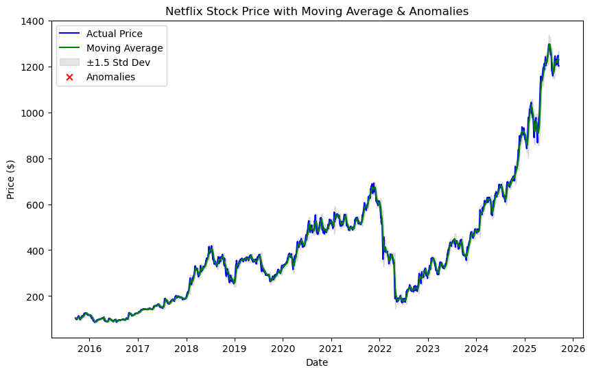

```python
plt.figure(figsize=(10,6))
plt.plot(df1.index, df1['y'], color='blue', label='Actual Price')
plt.plot(df1.index, df1['moving_average'], color='green', label='Moving Average')
plt.fill_between(df1.index, df1['lower'], df1['upper'], color='gray', alpha=0.2, label='±1.5 Std Dev')

plt.scatter(anomalies.index, anomalies['y'], color='red', marker='x', s=40, label='Anomalies')
plt.title("Netflix Stock Price with Moving Average & Anomalies")
plt.xlabel("Date"); plt.ylabel("Price ($)")
plt.legend()
plt.show()
```

# **Prophet**

```python
from prophet import Prophet
```

```python
import pandas as pd
import numpy as np
np.float_ = np.float64
import matplotlib.pyplot as plt

from prophet.plot import add_changepoints_to_plot
```

```python
df = pd.read_csv('/Users/linhle/Downloads/Netflix Stock Data (20215-2025).csv')
df['Date'] = pd.to_datetime(df['Date'], format="%m/%d/%y")
df = df.sort_values('Date')
df = df.rename(columns={'Close/Last': 'y'})
df['y'] = df['y'].replace(r'[\$,]', '', regex=True).astype(float)
df.columns = ['ds', 'y']
```

Visualize the actual stock price in dollars with manual vertical lines

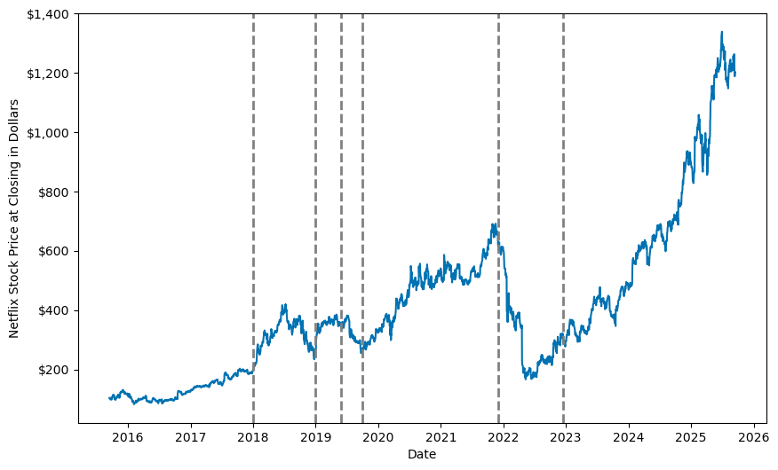

```python
import matplotlib.ticker as mticker
df['y'] = df['y'].replace(r'[\$,]', '', regex=True).astype(float)
plt.figure(figsize=(10, 6))
plt.plot(df['ds'], df['y'], color='#0072B2')
plt.axvline(pd.to_datetime('2018-01-01'), c='gray', ls='--', lw=2) #manually graph the vertical line
plt.axvline(pd.to_datetime('2019-01-01'), c='gray', ls='--', lw=2)
plt.axvline(pd.to_datetime('2019-06-01'), c='gray', ls='--', lw=2)
plt.axvline(pd.to_datetime('2019-10-01'), c='gray', ls='--', lw=2)
plt.axvline(pd.to_datetime('2022-12-15'), c='gray', ls='--', lw=2)
plt.axvline(pd.to_datetime('2021-12-01'), c='gray', ls='--', lw=2)
plt.xlabel("Date")
plt.ylabel("Netflix Stock Price at Closing in Dollars")

plt.gca().yaxis.set_major_formatter(mticker.StrMethodFormatter('${x:,.0f}'))

plt.show()
```

```python
print(df.head())
print(df.dtypes)
```

```
             ds       y
2513 2015-09-16  104.08
2512 2015-09-17  104.21
2511 2015-09-18  102.62
2510 2015-09-21  100.30
2509 2015-09-22   98.47
ds    datetime64[ns]
y            float64
dtype: object
```

Using multiplicative seasonality in Prophet to predict log-trasnformed stock price with no yearly seasonality since stock prices are not as likely to adjsut due to seasons. Log transformation is necessary to advoid negatives and allows Prophet to model relative or percentage adjusmtnets.

```
18:45:11 - cmdstanpy - INFO - Chain [1] start processing
18:45:12 - cmdstanpy - INFO - Chain [1] done processing
```

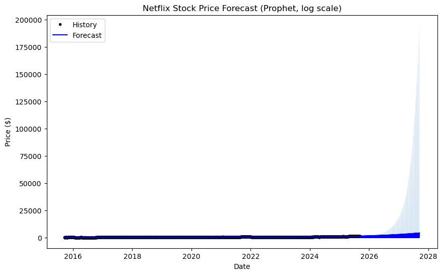

```python
import numpy as np
from prophet import Prophet
import matplotlib.pyplot as plt

df_log = df.copy()
df_log['y'] = np.log(df_log['y'])

m = Prophet(seasonality_mode='multiplicative', yearly_seasonality=False)
m.fit(df_log)

future = m.make_future_dataframe(periods=365*2)
forecast = m.predict(future)


forecast['yhat'] = np.exp(forecast['yhat'])
forecast['yhat_lower'] = np.exp(forecast['yhat_lower'])
forecast['yhat_upper'] = np.exp(forecast['yhat_upper'])

plt.figure(figsize=(10,6))
plt.plot(df['ds'], df['y'], 'k.', label='History')
plt.plot(forecast['ds'], forecast['yhat'], 'b-', label='Forecast')
plt.fill_between(forecast['ds'], forecast['yhat_lower'], forecast['yhat_upper'], alpha=0.2)
plt.title("Netflix Stock Price Forecast (Prophet, log scale)")
plt.ylabel("Price ($)")
plt.xlabel("Date")
plt.legend()
plt.show()
```

**Switch to calculate returns instead of raw stock price since Prophet would calculate percentage not raw price**

```python
import pandas as pd

df_returns = df[['ds','y']].copy().sort_values('ds')

df_returns['y'] = df_returns['y'].pct_change()
```

```python
from prophet import Prophet

m = Prophet(seasonality_mode='multiplicative', yearly_seasonality=False)
m.fit(df_returns)

# Forecast 2 years ahead
future = m.make_future_dataframe(periods=365*2)
forecast = m.predict(future)
```

```
18:45:20 - cmdstanpy - INFO - Chain [1] start processing
18:45:20 - cmdstanpy - INFO - Chain [1] done processing
```

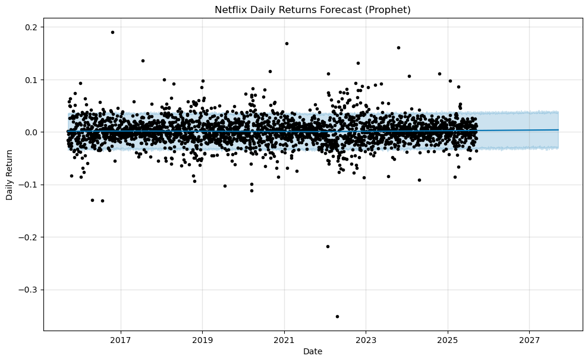

```python
import matplotlib.pyplot as plt

fig = m.plot(forecast)
plt.title("Netflix Daily Returns Forecast (Prophet)")
plt.ylabel("Daily Return")
plt.xlabel("Date")
plt.show()
```

```python
df_merged = forecast[['ds','yhat','yhat_lower','yhat_upper']].merge(
    df[['ds','y']], on='ds', how='left'
)

df['returns'] = df['y'].pct_change()
df = df.dropna()


df_merged = forecast[['ds','yhat','yhat_lower','yhat_upper']].merge(
    df[['ds','returns']], on='ds', how='left'
)
df_merged['anomaly'] = 0
df_merged.loc[df_merged['returns'] > df_merged['yhat_upper'], 'anomaly'] = 1
df_merged.loc[df_merged['returns'] < df_merged['yhat_lower'], 'anomaly'] = -1

anomalies = df_merged[df_merged['anomaly'] != 0]
anomalies
```

|  | ds | yhat | yhat_lower | yhat_upper | returns | anomaly |
| --- | --- | --- | --- | --- | --- | --- |
| 5 | 2015-09-24 | 0.001208 | -0.033620 | 0.034480 | 0.058020 | 1 |
| 9 | 2015-09-30 | 0.001225 | -0.029987 | 0.034918 | 0.049924 | 1 |
| 12 | 2015-10-05 | 0.001221 | -0.030661 | 0.034743 | 0.048440 | 1 |
| 15 | 2015-10-08 | 0.001219 | -0.030075 | 0.036187 | 0.063182 | 1 |
| 20 | 2015-10-15 | 0.001224 | -0.031575 | 0.033962 | -0.082918 | -1 |
| ... | ... | ... | ... | ... | ... | ... |
| 2414 | 2025-04-24 | 0.002398 | -0.031743 | 0.036855 | 0.045046 | 1 |
| 2460 | 2025-07-01 | 0.002520 | -0.033255 | 0.037209 | -0.034000 | -1 |
| 2472 | 2025-07-18 | 0.002515 | -0.031405 | 0.032950 | -0.050959 | -1 |
| 2474 | 2025-07-22 | 0.002554 | -0.030576 | 0.037117 | -0.035021 | -1 |
| 2510 | 2025-09-11 | 0.002621 | -0.030251 | 0.037252 | -0.035433 | -1 |

320 rows × 6 columns

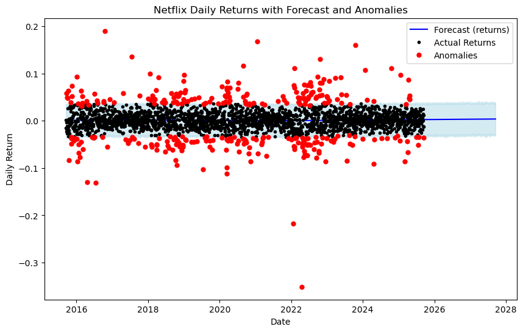

```python
fig, ax = plt.subplots(figsize=(10,6))
ax.plot(df_merged['ds'], df_merged['yhat'], 'b-', label="Forecast (returns)")
ax.fill_between(df_merged['ds'], df_merged['yhat_lower'], df_merged['yhat_upper'], color='lightblue', alpha=0.5)

ax.plot(df_merged['ds'], df_merged['returns'], 'k.', label="Actual Returns")

ax.plot(anomalies['ds'], anomalies['returns'], 'ro', markersize=5, label="Anomalies")

ax.set_title("Netflix Daily Returns with Forecast and Anomalies")
ax.set_xlabel("Date")
ax.set_ylabel("Daily Return")
ax.legend()
plt.show()
```

Adding monthly and weekly seasonality since stock price might have monthly and weekly cycle, allowing more robust identification of anamolies that do not belong to the trend. Using multiplicative seasonality since stock price scale with levels and not in absolute terms.

```
18:47:16 - cmdstanpy - INFO - Chain [1] start processing
18:47:16 - cmdstanpy - INFO - Chain [1] done processing
```

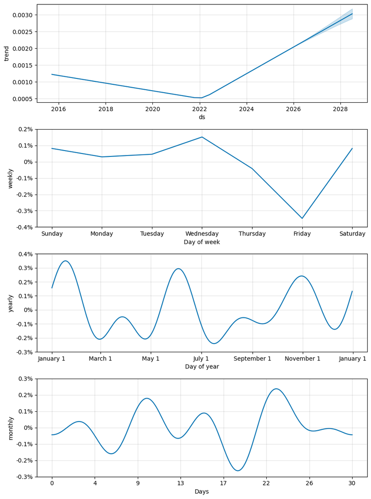

```python
m = Prophet(
    seasonality_mode='multiplicative',
    weekly_seasonality=False,
    yearly_seasonality=False,
    daily_seasonality=False,
    changepoint_prior_scale=0.02,
    seasonality_prior_scale=2.0
)

m.add_seasonality(name='weekly',  period=7,    fourier_order=3, mode='multiplicative')
m.add_seasonality(name='monthly', period=30.5, fourier_order=5, mode='multiplicative')
m.add_seasonality(name='yearly',  period=365.25, fourier_order=6, mode='multiplicative')

m.fit(df_lr)

future = m.make_future_dataframe(periods=365*2, freq='B')
forecast = m.predict(future)

fig = m.plot_components(forecast)
plt.show()
```

Add where Prophet think the trend adjust

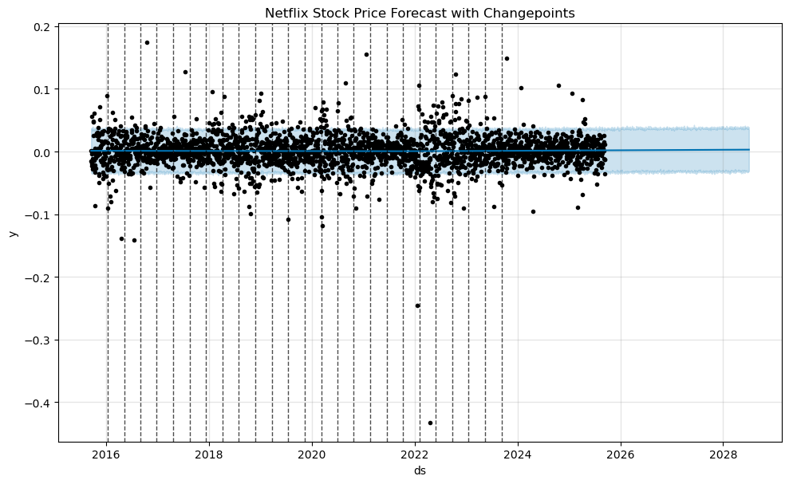

```python
fig1 = m.plot(forecast)

for cp in m.changepoints:
    plt.axvline(cp, color='k', ls='--', lw=1, alpha=0.7)

plt.title("Netflix Stock Price Forecast with Changepoints")
plt.show()
```

Adding special events to identify known anamolies including the start of Covid's stay at home order (when people stay at home more, the hypothesis is that they would stream more entertainment), the start of Covid's restricitons relaxation (the hypothesis is that people would start to go out and socialize more, hence less time for streaming), the Interest Rate Increase (the idea is that the market would respond to interest rate adjustment), and the WAG strike (the idea is that people would invest less when streaming service was under strike, making them more exposed to losses).

```python
SpecialTimes = pd.DataFrame([
    {'holiday':'Covid-Stay-at-Home',
     'ds': pd.to_datetime('2020-03-21'),
     'lower_window': 0,
     'upper_window': 365},
    {'holiday':'Covid-Lock-Down-Relax',
     'ds': pd.to_datetime('2021-05-01'),
     'lower_window': 0,
     'upper_window': 90},
    {'holiday':'Interest-Rate-Increase',
     'ds': pd.to_datetime('2022-05-01'),
     'lower_window': 0,
     'upper_window': 230},
    {'holiday':'WAG Strike',
     'ds': pd.to_datetime('2023-05-05'),
     'lower_window': 0,
     'upper_window': 147}])
```

Adding weekly, yearly, and monthly trend to better identify anamolies that does not follow the trend.

```
18:50:12 - cmdstanpy - INFO - Chain [1] start processing
18:50:12 - cmdstanpy - INFO - Chain [1] done processing
```

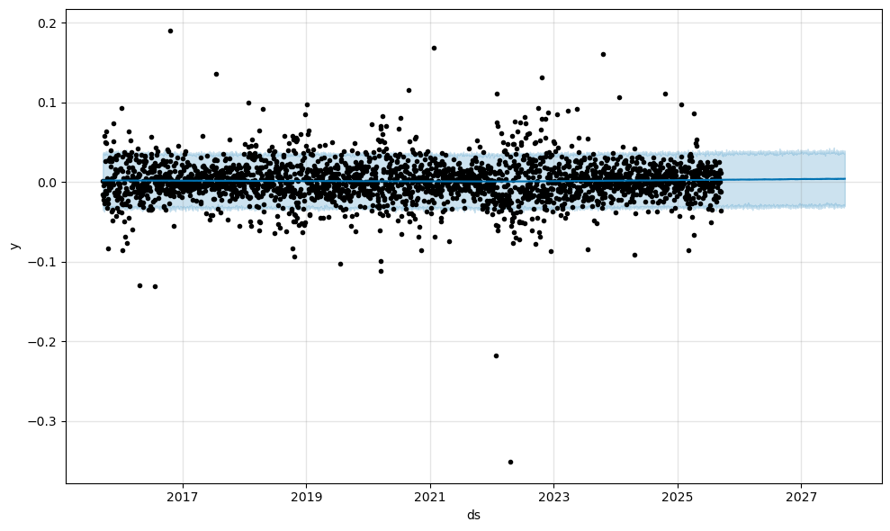

```python
model = Prophet(seasonality_mode='multiplicative', holidays=SpecialTimes)
model.add_seasonality(name='weekly',  period=7,    fourier_order=3, mode='multiplicative')
model.add_seasonality(name='monthly', period=30.5, fourier_order=5, mode='multiplicative')
model.add_seasonality(name='yearly',  period=365.25, fourier_order=6, mode='multiplicative')
model.fit(df_returns)
future = model.make_future_dataframe(periods=365*2)
forecast = model.predict(future)
fig = model.plot(forecast)
plt.show()
```

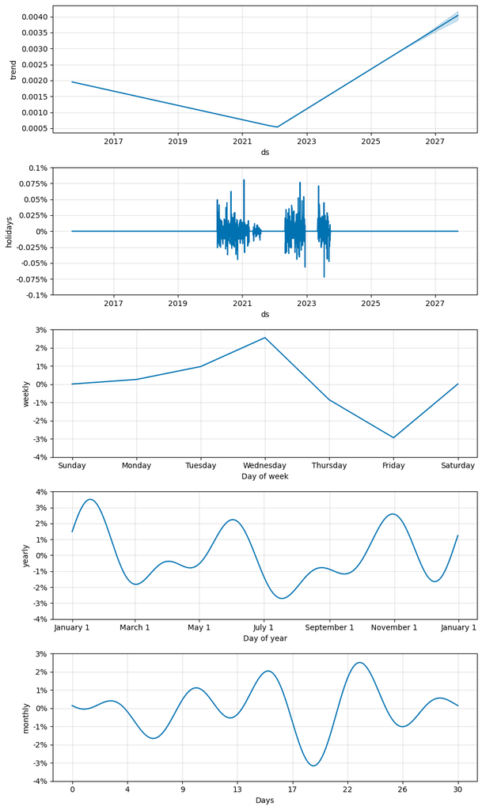

```python
fig = model.plot_components(forecast)
plt.show()
```

Plotting anamolies after fitting special events to visualize.

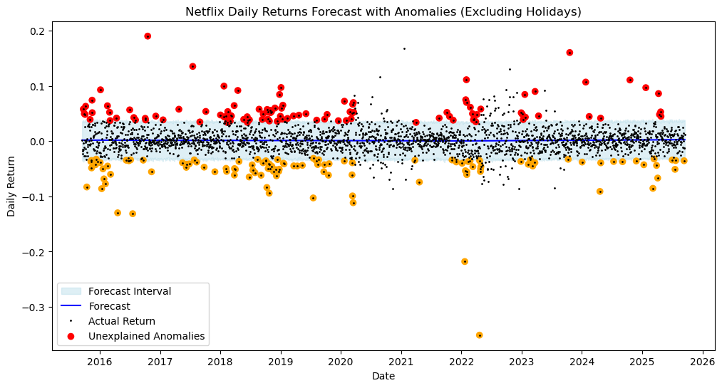

```python
df_actuals = df_returns[['ds','y']].copy()
df_actuals = df_actuals.rename(columns={'y':'return'})

holiday_ranges = []
for _, row in SpecialTimes.iterrows():
    start = row['ds'] + pd.Timedelta(days=row['lower_window'])
    end   = row['ds'] + pd.Timedelta(days=row['upper_window'])
    holiday_ranges.append(pd.date_range(start, end))

holiday_dates = pd.DatetimeIndex(sorted(set([d for r in holiday_ranges for d in r])))

merged = pd.merge(
    df_actuals,
    forecast[['ds','yhat','yhat_lower','yhat_upper']].rename(
        columns={'yhat':'ret_hat','yhat_lower':'ret_hat_lower','yhat_upper':'ret_hat_upper'}),
    on='ds', how='left'
)

merged['anomaly'] = 0

merged.loc[merged['return'] > merged['ret_hat_upper'], 'anomaly'] = 1
merged.loc[merged['return'] < merged['ret_hat_lower'], 'anomaly'] = -1

merged.loc[merged['ds'].isin(holiday_dates), 'anomaly'] = 0


import matplotlib.pyplot as plt
plt.figure(figsize=(12,6))

plt.fill_between(merged['ds'], merged['ret_hat_lower'], merged['ret_hat_upper'],
                 color='lightblue', alpha=0.4, label='Forecast Interval')

plt.plot(merged['ds'], merged['ret_hat'], 'b-', label='Forecast')

plt.plot(merged['ds'], merged['return'], 'k.', ms=2, label='Actual Return')

anoms = merged[merged['anomaly'] != 0]
plt.scatter(anoms['ds'], anoms['return'],
            c=np.where(anoms['anomaly']==1,'red','orange'),
            label='Unexplained Anomalies')

plt.title("Netflix Daily Returns Forecast with Anomalies (Excluding Holidays)")
plt.xlabel("Date"); plt.ylabel("Daily Return")
plt.legend(); plt.show()
```

**Predict with future shocks**

Predicting how future special events would impact returns to improve prediction model.

```
18:50:31 - cmdstanpy - INFO - Chain [1] start processing
18:50:32 - cmdstanpy - INFO - Chain [1] done processing
```

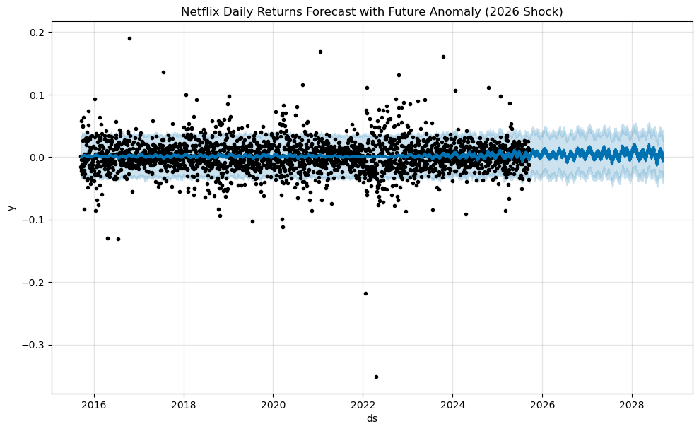

```python
FutureAnomaly = pd.DataFrame([
    {'holiday': 'Future-Market-Shock',
     'ds': pd.to_datetime('2026-06-01'),
     'lower_window': 0,
     'upper_window': 30}
])

AllEvents = pd.concat([SpecialTimes, FutureAnomaly])

model = Prophet(seasonality_mode='multiplicative',
                holidays=AllEvents)
model.fit(df_returns)

future = model.make_future_dataframe(periods=365*3)
forecast = model.predict(future)

fig = model.plot(forecast)
plt.title("Netflix Daily Returns Forecast with Future Anomaly (2026 Shock)")
plt.show()
```